# Simulate data using behavioral model and perform parameter recovery

There are 3 models with different parameter combinations:

1. **The Bayesian model (Schwöbel et al. 2021):**  
   **a.** With 3 parameters: a policy forgetting rate $\lambda_{\pi}$, a reward forgetting rate $\lambda_{r}$, and a decision temparature $\beta$.  
   **b.** With 4 parameters: a policy forgetting rate $\lambda_{\pi}$, a reward forgetting rate $\lambda_{r}$, a decision temparature $\beta$, and a habitual tendency $h$.
2. **The original model-free/model-based (MF/MB) model (Daw et al. 2005, 2011):**  
   **a.** With 4 parameters: a weighting parameters $\omega$, a decision temperature $\beta$, a learning rate $\alpha$, and a dicount factor $\lambda$.  
   **b.** With 5 parameters: a weighting parameter $\omega$, a decision temperature $\beta$, a learning rate $\alpha$, a dicount factor $\lambda$, and a repetition/perserveration parameter $p$.
3. **A newer MF/MB version that is better for fitting (Otto et al. 2013):**  
   **a.** With 4 parameters: a MF weight parameter $\beta_{MF}$, a MB weight parameter $\beta_{MB}$, a learning rate $\alpha$, and a dicount factor $\lambda$.  
   **b.** With 4 parameters: a MF weight parameter $\beta_{MF}$, a MB weight parameter $\beta_{MB}$, a learning rate $\alpha$, and a dicount factor $\lambda$.

Tell python that the code in the submodule is code that we want to import and run

```python
import sys
sys.path.append('code/BalancingControl')

import recovery_utils as ru
import inference_twostage as inf
```

```
torch threads 1
Running on device cpu
```

Other imports that we need for simulation, inference, and plotting

```python
import torch
import pyro

import os
from scipy.io import loadmat
import matplotlib.pylab as plt
import seaborn as sns
import pandas as pd
import glob
import jsonpickle as pickle
import json
import gc
```

Where second stage random walks from the experiment are stored

```python
Rho_data_fname = os.path.join("experiment", "dawrandomwalks.mat")
```

Define where results should be saved

```python
results_folder = "results"
simulation_folder = os.path.join(results_folder, "simulations")
recovery_folder = os.path.join(results_folder, "recovery")
```

#### Global experiment parameters

```python
# number of simulated agents/participants
n_agents = 10
```

```python
trials =  201#number of trials
T = 3 #number of time steps in each trial
nb = 4 # number of bandits, ie second level rewards
ns = 3+nb #number of states
no = ns #number of observations
na = 2 #number of actions
npi = na**(T-1) #number of policies
nr = 2 #number of rewards
never_reward = ns-nb # states that dont generate rewards

# prob for invalid answer (e.g. no reply). Same frequency as in the real data
p_invalid = 1.-1./201.

# make global parameter dict:
global_experiment_parameters = {"trials": trials, "T": T, "nb": nb, "ns": ns, "no": no, "na": na, "npi": npi, "nr": nr, "never_reward": never_reward, "p_invalid": p_invalid}
```

Define states and transition matrices

```python
#generating probability of observations in each state / unity matrix
A = torch.eye(no)


#state transition generative probability (matrix)
B = torch.zeros((ns, ns, na))
b1 = 0.7
nb1 = 1.-b1
b2 = 0.7
nb2 = 1.-b2

B[:,:,0] = torch.tensor([[  0,  0,  0,  0,  0,  0,  0,],
                      [ b1,  0,  0,  0,  0,  0,  0,],
                      [nb1,  0,  0,  0,  0,  0,  0,],
                      [  0,  1,  0,  1,  0,  0,  0,],
                      [  0,  0,  0,  0,  1,  0,  0,],
                      [  0,  0,  1,  0,  0,  1,  0,],
                      [  0,  0,  0,  0,  0,  0,  1,],])

B[:,:,1] = torch.tensor([[  0,  0,  0,  0,  0,  0,  0,],
                      [nb2,  0,  0,  0,  0,  0,  0,],
                      [ b2,  0,  0,  0,  0,  0,  0,],
                      [  0,  0,  0,  1,  0,  0,  0,],
                      [  0,  1,  0,  0,  1,  0,  0,],
                      [  0,  0,  0,  0,  0,  1,  0,],
                      [  0,  0,  1,  0,  0,  0,  1,],])

# add to parameter dict
global_experiment_parameters["A"] = A
global_experiment_parameters["B"] = B
```

Load and plot reward probabilities

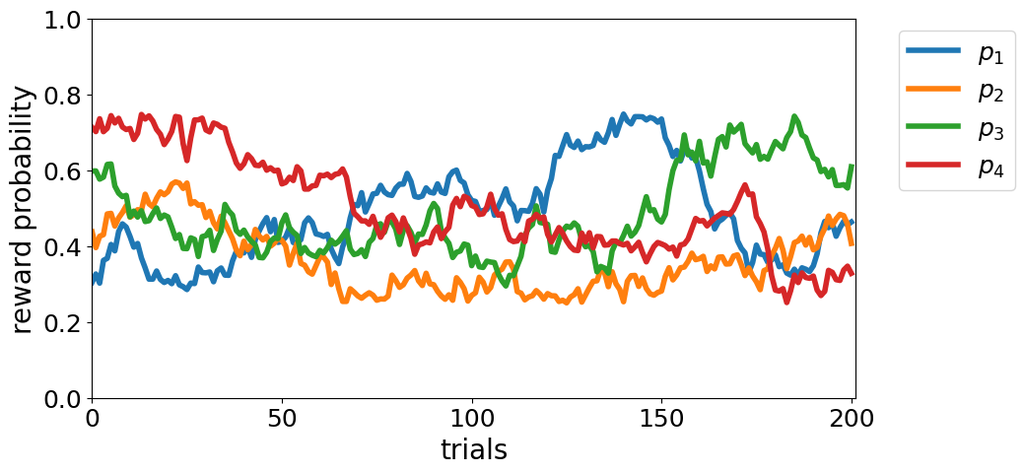

```python
rew_probs = loadmat(Rho_data_fname)['dawrandomwalks']
assert trials==rew_probs.shape[-1]

Rho = torch.zeros((trials, nr, ns))

Rho[:,1,:never_reward] = 0.
Rho[:,0,:never_reward] = 1.

Rho[:,1,never_reward:never_reward+2] = torch.from_numpy(rew_probs[0,:,:]).permute((1,0))
Rho[:,0,never_reward:never_reward+2] = torch.from_numpy(1-rew_probs[0,:,:]).permute((1,0))

Rho[:,1,never_reward+2:] = torch.from_numpy(rew_probs[1,:,:]).permute((1,0))
Rho[:,0,never_reward+2:] = torch.from_numpy(1-rew_probs[1,:,:]).permute((1,0))

plt.figure(figsize=(10,5))
for i in range(4):
    plt.plot(Rho[:,1,3+i], label="$p_{}$".format(i+1), linewidth=4)
plt.ylim([0,1])
plt.yticks(torch.arange(0,1.1,0.2),fontsize=18)
plt.ylabel("reward probability", fontsize=20)
plt.xlim([-0.1, trials+0.1])
plt.xticks(range(0,trials+1,50),fontsize=18)
plt.xlabel("trials", fontsize=20)
plt.legend(fontsize=18, bbox_to_anchor=(1.04,1))
plt.savefig(os.path.join(results_folder, "twostep_prob.svg"),dpi=300)
plt.show()

# add to parameter dict
global_experiment_parameters["Rho"] = Rho
```

Now we can start :)

### 1. BCC:

### 1.a 3 parameter version

Simulation pre-setup

```python
# set parameters and their names

infer_h = False

prefix = "BCC_"
param_names = ["policy rate", "reward rate", "dec temp", "habitual tendency"]
model_name = "Bayesian prior-based contextual control model"

if infer_h:
    n_pars = 4
    h_str = "4param"
else:
    n_pars = 3
    h_str = "3param"
    param_names = param_names[:-1]

# choose max decision temperature for numerical stability
max_dt = 6

# prepare for saving results
# make base filename and folder string
fname_base = prefix+h_str+"_simulation_"
print(fname_base)
# define folder where we want to save data
base_dir = os.path.join(simulation_folder,fname_base[:-1])
```

```
BCC_3param_simulation_
```

**Decide** for running or loading simulated data

```python
run_simulation = False
```

**Either:** (re)run simulations, save parameter and behavior

```python
if run_simulation:
    # make directory if it doesnt exist
    if fname_base[:-1] not in os.listdir(simulation_folder):
        os.mkdir(base_dir)

    # choose whether olf simulations in this folder should be deleted.
    remove_old = True

    print("simulating "+str(n_agents)+" agents...\nrandomly generating true parameter values...")
    stayed_arr, true_vals, data = ru.run_BCC_simulations(n_agents, infer_h, fname_base, base_dir, **global_experiment_parameters, max_dt=max_dt, remove_old=remove_old)
```

**Or:** load stored simulation results

```python
if not run_simulation:
    print("loading simulated outputs...")

    stayed_arr, true_vals, data = ru.load_simulation_outputs(base_dir)

    n_true = true_vals["subject"].max() + 1
    n_data = data["subject"].max() + 1

    assert n_true == n_data == n_agents, f"the numbers of agents dont match! They are: {n_true}, {n_data}, {n_agents}. Probably rerun simulations to fix."

    print("true values are:")
    print(true_vals)
```

```
loading simulated outputs...
true values are:
{'subject': tensor([[0, 1, 2, 3, 4, 5, 6, 7, 8, 9]]), 'policy rate': tensor([[0.3573, 0.1636, 0.6217, 0.3581, 0.8585, 0.5793, 0.9261, 0.1477, 0.2566,
         0.2057]]), 'reward rate': tensor([[2.6740e-01, 3.9145e-01, 4.0686e-04, 4.6921e-01, 5.5614e-03, 7.8240e-01,
         1.7969e-01, 8.8372e-02, 4.5967e-01, 3.8955e-01]]), 'dec temp': tensor([[4.2458, 2.0533, 1.3649, 1.8423, 1.6207, 3.7696, 1.4883, 6.2257, 1.0740,
         6.0640]]), 'habitual tendency': tensor([[1, 1, 1, 1, 1, 1, 1, 1, 1, 1]])}
```

Plot simulated stay probability

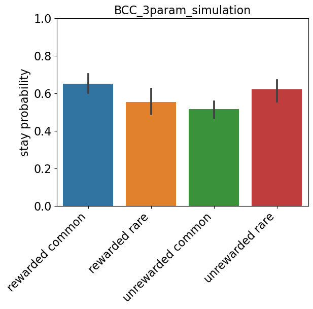

```python
bar_names = ["rewarded common", "rewarded rare", "unrewarded common", "unrewarded rare"]

plt.figure()
g = sns.barplot(data=stayed_arr)
g.set_xticklabels(bar_names, rotation=45, horizontalalignment='right', fontsize=16)
plt.ylim([0,1])
plt.yticks(torch.arange(0,1.1,0.2),fontsize=16)
plt.ylabel("stay probability", fontsize=16)
plt.title(fname_base[:-1], fontsize=16)
plt.savefig(os.path.join(base_dir,"simulated_stay_probs.svg"),dpi=300)
plt.show()
```

#### Inference

Set up agent

```python
# prepare for saving results
# make base filename and folder string
fname_base = prefix+h_str+"_recovery_"
print(fname_base)
# define folder where we want to save data
base_dir = os.path.join(recovery_folder,fname_base[:-1])

# make directory if it doesnt exist
if fname_base[:-1] not in os.listdir(recovery_folder):
    os.mkdir(base_dir)

# remove old inference?
remove_old = True

# if it does exist, empty previous results, if we want that (remove_old==True)
if remove_old:

    svgs = glob.glob(os.path.join(base_dir,"*.svg"))
    for file in svgs:
        os.remove(file)

    csvs = glob.glob(os.path.join(base_dir,"*.csv"))
    for file in csvs:
        os.remove(file)

    saves = glob.glob(os.path.join(base_dir,"*.save"))
    for file in saves:
        os.remove(file)

    agents = glob.glob(os.path.join(base_dir,"twostage_agent*"))
    for file in agents:
        os.remove(file)

    outputs = glob.glob(os.path.join(base_dir,"*.json"))
    for file in outputs:
        os.remove(file)

# perception args for init, will instantly be over-written, but have to be set for initialization
pol_lambda = torch.tensor([1.])
r_lambda = torch.tensor([0.5])
dec_temp = torch.tensor([2.])
alpha_0 = torch.tensor([1.])

perception_args = {"policy rate": pol_lambda, "reward rate": r_lambda, "dec temp": dec_temp, "habitual tendency": alpha_0}

avg = True

agent_par_list = [avg, perception_args, infer_h, data["valid"]]
bayes_agent, bayes_perception = ru.set_up_Bayesian_agent(agent_par_list, **global_experiment_parameters, nsubs=n_agents)

print('analyzing '+str(n_agents)+' data sets')
```

```
BCC_3param_recovery_
analyzing 10 data sets
```

Set up group inference

```python
inferrer = inf.GeneralGroupInference(bayes_agent, data)

num_particles = 15
```

Run main inference loop, plot intermediate and end results

```
this is inference using <class 'inference_twostage.GeneralGroupInference'>
taking steps 1 to 2 out of total 600
```

```
Mean ELBO 2705.65: 100%|████████████████████████████████████████████████████████████████████████████████████████████████████████████████████████████████████████| 2/2 [00:17<00:00,  8.66s/it]
```

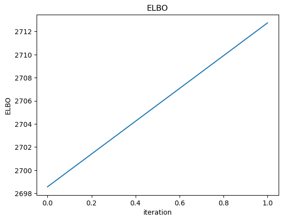

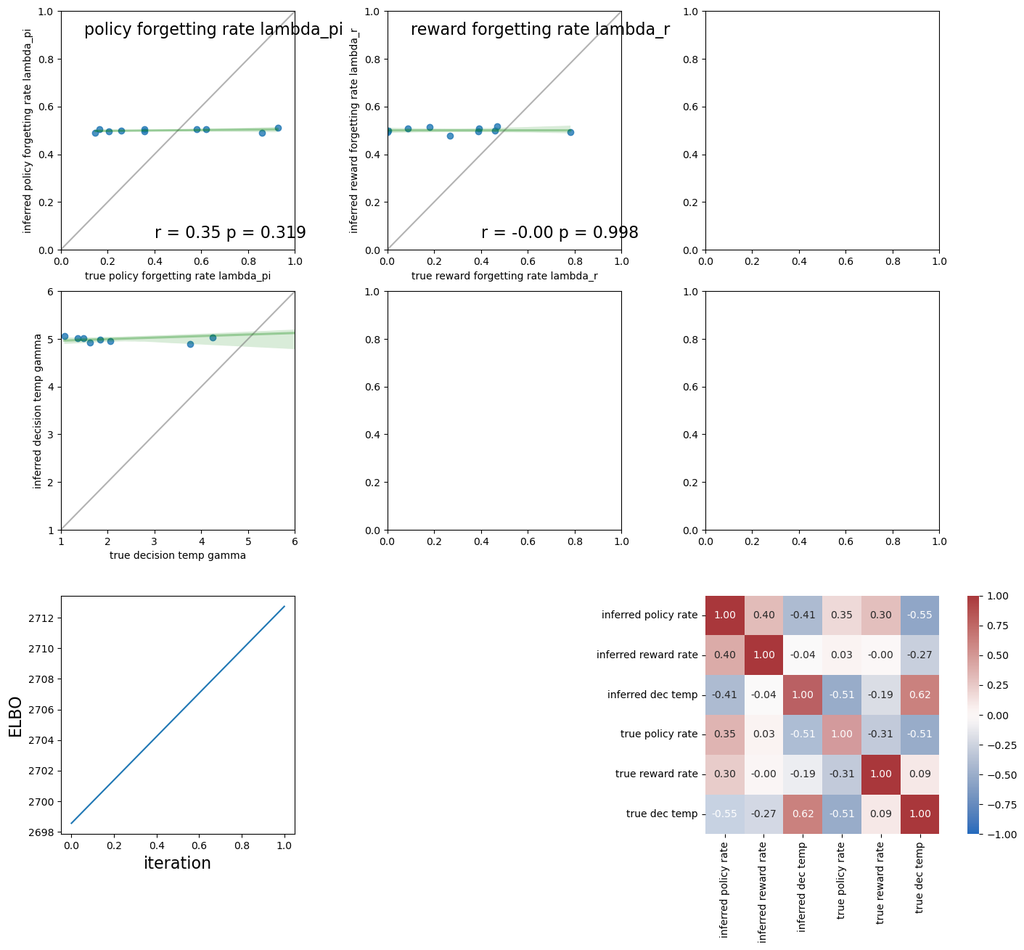

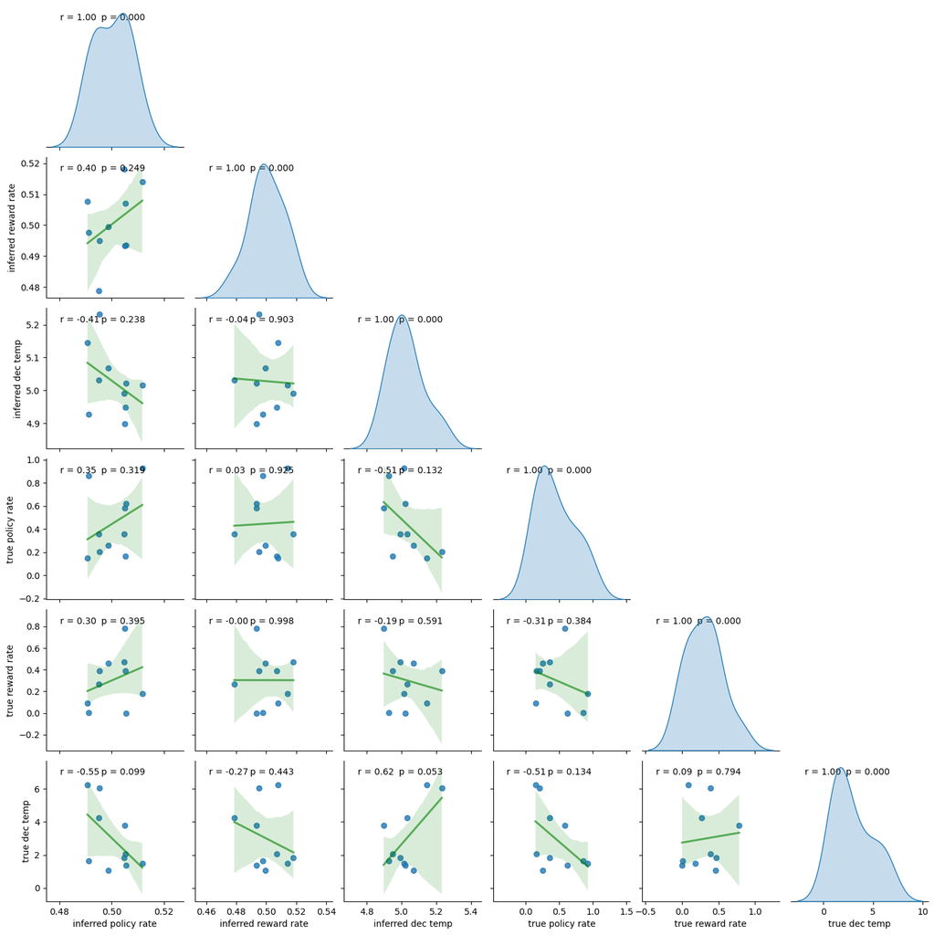

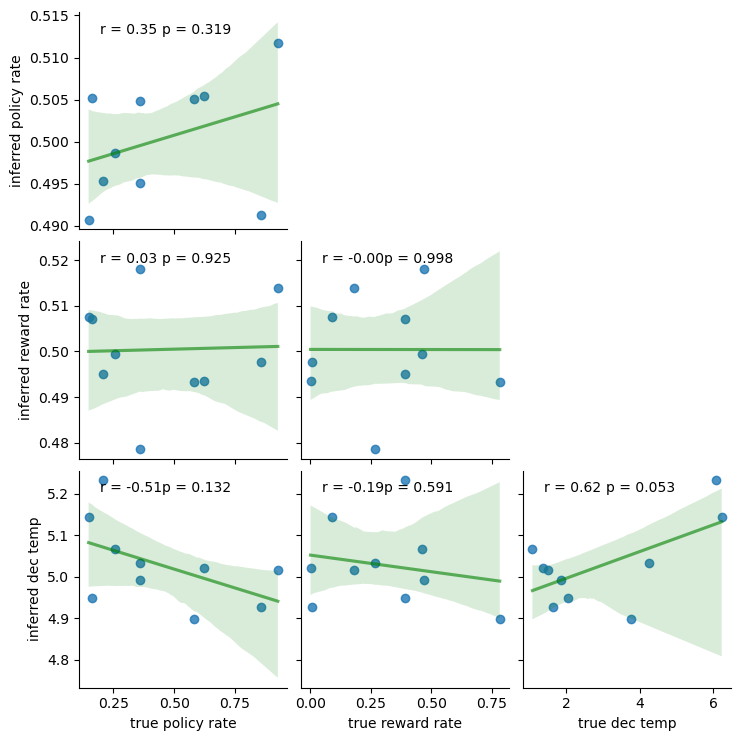

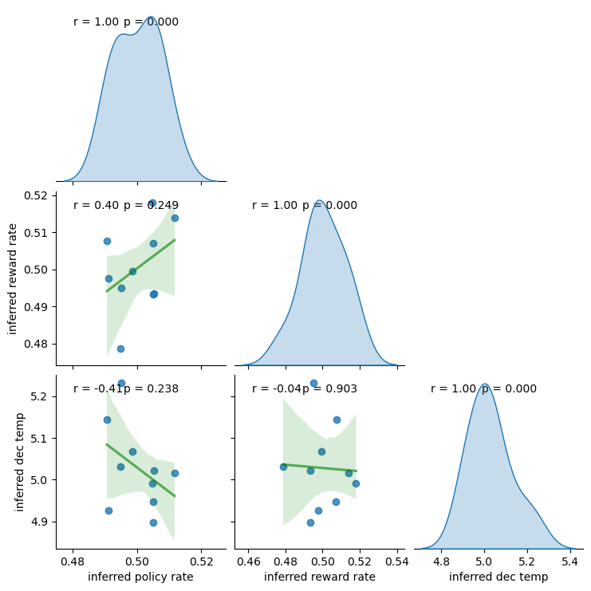

```
This is recovery for the twostage task using the Bayesian prior-based contextual control model(BCC_3param) with 10 agents.
The settings are: infer h False
taking steps 3 to 4 out of total 600
```

```
Mean ELBO 2703.73:  50%|████████████████████████████████████████████████████████████████████                                                                    | 1/2 [00:09<00:09,  9.76s/it]
```

[output not shown]

[output cut: 73 more lines]

[output not shown]

```python
print("this is inference using", type(inferrer))

num_steps = 600
size_chunk = 2
total_num_iter_so_far = 0

for i in range(total_num_iter_so_far, num_steps, size_chunk):
    print('taking steps '+str(i+1)+' to '+str(i+size_chunk)+' out of total '+str(num_steps))

    fname_str = fname_base + str(total_num_iter_so_far+size_chunk)+'_'+str(n_agents)+'agents'

    ru.infer(inferrer, size_chunk, fname_str, num_particles, recovery_folder)
    total_num_iter_so_far += size_chunk
    full_df, smaller_df, sample_df = ru.sample_posterior(inferrer, param_names, true_vals, fname_str, recovery_folder)

    # ru.plot_posterior(full_df, fname_str)
    # ru.plot_correlations(full_df, fname_str)

    ru.plot_results(sample_df, param_names, fname_str, inferrer.loss, smaller_df, recovery_folder, max_dt)

    print("This is recovery for the twostage task using the "+model_name+"("+prefix+h_str+")"+" with "+str(n_agents)+" agents.")
    print("The settings are: infer h", infer_h)
```